# Métodos Computacionais para Estatística e Otimização

Lista 3 - Luiz Henrique Barretta Francisco

Considere o conjunto de dados sobre voos e operações aéreas disponibilizado pela ANAC (Agência Nacional de Aviação Comercial) no seguinte endereço clique aqui. O arquivo chamado de *Dados_Estatisticos.csv* apresenta uma série de informações sobre as operadores aéreas que atuam no Brasil. Forneça o código R usando o framework {tidyverse} para responder cada uma das seguintes questões práticas.

1. Considere que é de interesse visualizar a série temporal (anual) do número de decolagens para as 10 empresas nacionais que mais decolaram no período disponível de dados. Faça duas visualizações uma para enfatizar a comparação entre as empresas e outra para enfatizar a visualização da série de cada empresa. Considere apenas os registros que tenham o número de decolagens.

```r
top_empresas <- df %>%
  filter(EMPRESA_NACIONALIDADE == "BRASILEIRA", !is.na(DECOLAGENS)) %>%
  group_by(EMPRESA_NOME) %>%
  summarise(Total = sum(DECOLAGENS, na.rm = TRUE)) %>%
  arrange(desc(Total)) %>%
  slice_head(n = 10) %>%
  pull(EMPRESA_NOME)

dados_top <- df %>%
  filter(EMPRESA_NOME %in% top_empresas, !is.na(DECOLAGENS)) %>%
  group_by(ANO, EMPRESA_NOME) %>%
  summarise(Total_Decolagens = sum(DECOLAGENS, na.rm = TRUE)) %>%
  ungroup()
```

[output not shown]

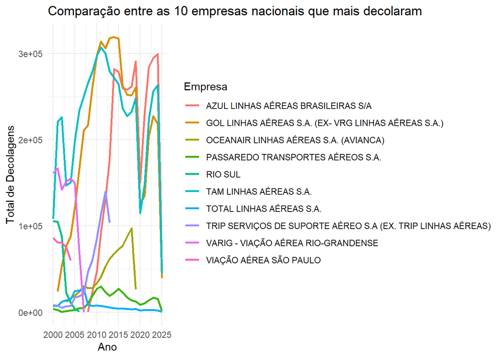

```r
ggplot(dados_top, aes(x = ANO, y = Total_Decolagens, color = EMPRESA_NOME)) +
  geom_line(size = 1) +
  labs(title = "Comparação entre as 10 empresas nacionais que mais decolaram",
       x = "Ano", y = "Total de Decolagens", color = "Empresa") +
  theme_minimal()
```

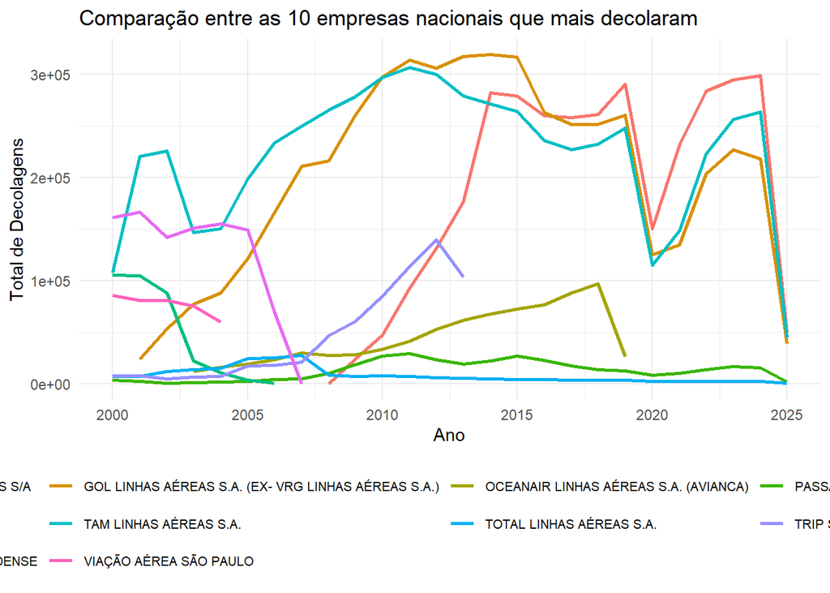

```r
ggplot(dados_top, aes(x = ANO, y = Total_Decolagens, color = EMPRESA_NOME)) +
  geom_line(size = 1) +
  labs(title = "Comparação entre as 10 empresas nacionais que mais decolaram",
       x = "Ano", y = "Total de Decolagens", color = "Empresa") +
  theme_minimal() +
  theme(legend.position = "bottom",
        legend.text = element_text(size = 8),
        legend.title = element_text(size = 9)) +
  guides(color = guide_legend(nrow = 3, byrow = TRUE))
```

2. Faça uma visualização de dados comparar o número de passageiros pagantes entre empresas nacionais e estrangeiras ao longo dos anos.

[output not shown]

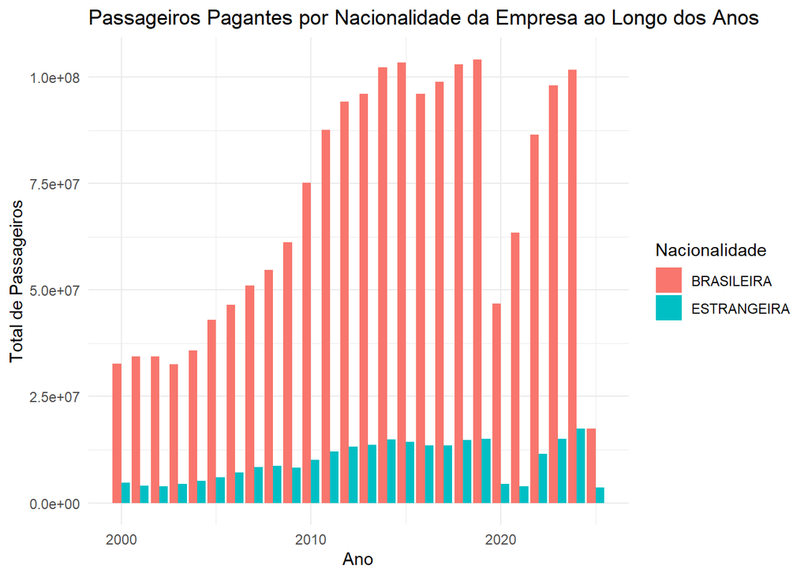

```r
df %>%
  filter(!is.na(PASSAGEIROS_PAGOS)) %>%
  group_by(ANO, EMPRESA_NACIONALIDADE) %>%
  summarise(Total_Passageiros = sum(PASSAGEIROS_PAGOS, na.rm = TRUE)) %>%
  ggplot(aes(x = ANO, y = Total_Passageiros, fill = EMPRESA_NACIONALIDADE)) +
  geom_col(position = "dodge") +
  labs(title = "Passageiros Pagantes por Nacionalidade da Empresa ao Longo dos Anos",
       x = "Ano", y = "Total de Passageiros", fill = "Nacionalidade") +
  theme_minimal()
```

3. Faça uma visualização de dados comparar o número de passageiros pagantes entre empresas nacionais e estrangeiras de acordo com o grupo de voo.

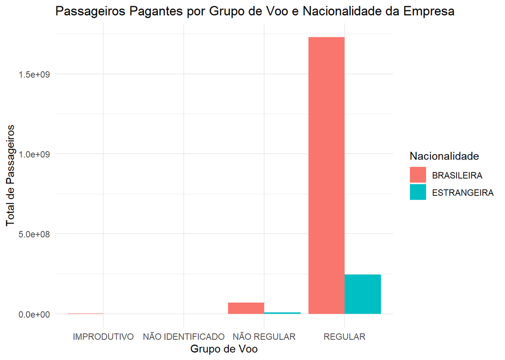

```r
df %>%
  filter(!is.na(PASSAGEIROS_PAGOS), !is.na(GRUPO_DE_VOO)) %>%
  group_by(GRUPO_DE_VOO, EMPRESA_NACIONALIDADE) %>%
  summarise(Total_Passageiros = sum(PASSAGEIROS_PAGOS, na.rm = TRUE)) %>%
  ggplot(aes(x = GRUPO_DE_VOO, y = Total_Passageiros, fill = EMPRESA_NACIONALIDADE)) +
  geom_col(position = "dodge") +
  labs(title = "Passageiros Pagantes por Grupo de Voo e Nacionalidade da Empresa",
       x = "Grupo de Voo", y = "Total de Passageiros", fill = "Nacionalidade") +
  theme_minimal()
```

4. Faça uma visualização para enfatizar a distribuição da variável número de passageiros pagantes de acordo com a região de origem e natureza do voo. Enfatize a comparação entre DOMÉSTICA e INTERNACIONAL para cada região de origem. Para criar o gráfico use o log10 da variável PASSAGEIROS_PAGOS.

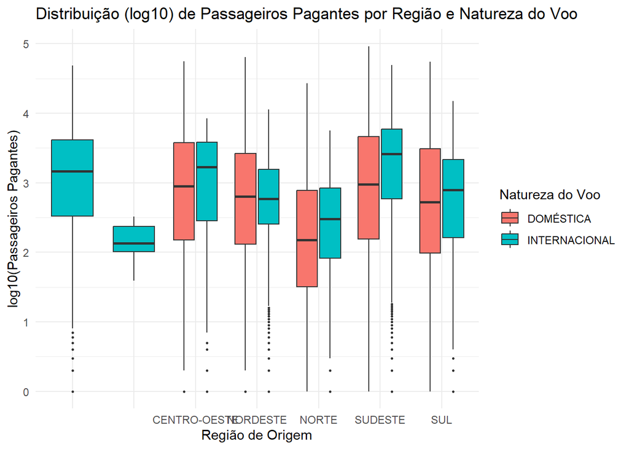

```r
df %>%
  filter(!is.na(PASSAGEIROS_PAGOS), PASSAGEIROS_PAGOS > 0,
         !is.na(AEROPORTO_DE_ORIGEM_REGIAO), !is.na(NATUREZA)) %>%
  mutate(PASSAGEIROS_LOG = log10(PASSAGEIROS_PAGOS)) %>%
  ggplot(aes(x = AEROPORTO_DE_ORIGEM_REGIAO, y = PASSAGEIROS_LOG, fill = NATUREZA)) +
  geom_boxplot(outlier.size = 0.5) +
  labs(title = "Distribuição (log10) de Passageiros Pagantes por Região e Natureza do Voo",
       x = "Região de Origem", y = "log10(Passageiros Pagantes)", fill = "Natureza do Voo") +
  theme_minimal()
```

5. Crie uma variável que indique a eficiencia no uso do combustível como sendo a razão entre o DISTANCIA_VOADA_KM e COMBUSTIVEL_LITROS. Compare as empresas de acordo com a região de origem e destino. Use a escala y em log10 para facilitar a comparação das regiões.

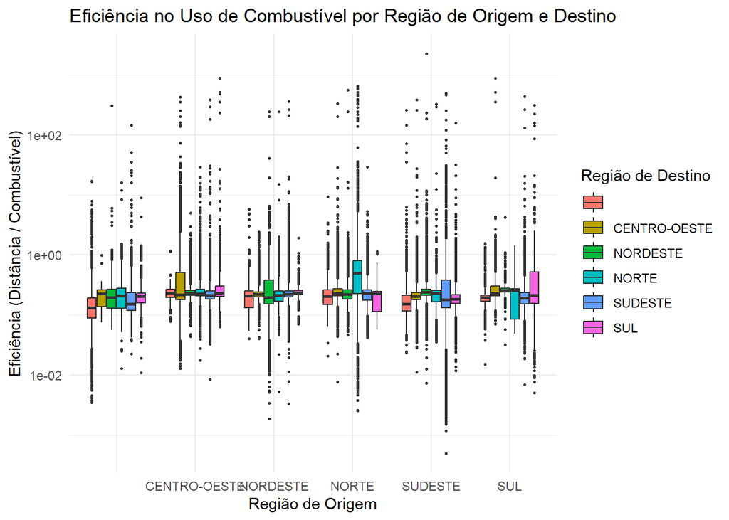

```r
df %>%
  filter(!is.na(DISTANCIA_VOADA_KM), !is.na(COMBUSTIVEL_LITROS), COMBUSTIVEL_LITROS > 0,
         !is.na(AEROPORTO_DE_ORIGEM_REGIAO), !is.na(AEROPORTO_DE_DESTINO_REGIAO)) %>%
  mutate(EFICIENCIA = DISTANCIA_VOADA_KM / COMBUSTIVEL_LITROS) %>%
  ggplot(aes(x = AEROPORTO_DE_ORIGEM_REGIAO, y = EFICIENCIA, fill = AEROPORTO_DE_DESTINO_REGIAO)) +
  geom_boxplot(outlier.size = 0.5) +
  scale_y_log10() +
  labs(title = "Eficiência no Uso de Combustível por Região de Origem e Destino",
       x = "Região de Origem", y = "Eficiência (Distância / Combustível)", fill = "Região de Destino") +
  theme_minimal()
```

6. Faça uma visualização para mostrar a relação entre o consumo de combustível e a distância voada. Considere empresas nacionais e internacionais e os diferentes anos para enriquecer a visualização. Considere transformar as variáveis e use alguma forma estatística para enfatizar a forma do relacionamento.

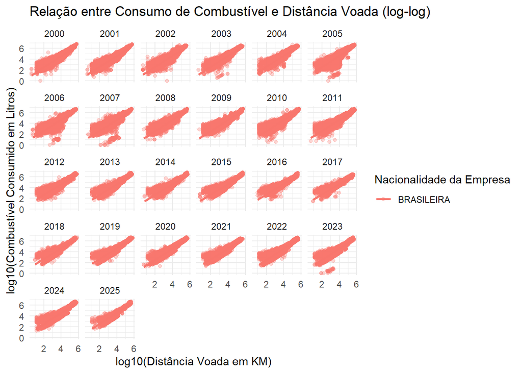

```r
df %>%
  filter(!is.na(COMBUSTIVEL_LITROS), !is.na(DISTANCIA_VOADA_KM),
         COMBUSTIVEL_LITROS > 0, DISTANCIA_VOADA_KM > 0) %>%
  mutate(log_comb = log10(COMBUSTIVEL_LITROS),
         log_dist = log10(DISTANCIA_VOADA_KM)) %>%
  ggplot(aes(x = log_dist, y = log_comb, color = EMPRESA_NACIONALIDADE)) +
  geom_point(alpha = 0.3) +
  geom_smooth(method = "lm", se = FALSE) +
  facet_wrap(~ANO) +
  labs(title = "Relação entre Consumo de Combustível e Distância Voada (log-log)",
       x = "log10(Distância Voada em KM)", y = "log10(Combustível Consumido em Litros)",
       color = "Nacionalidade da Empresa") +
  theme_minimal()
```

8. Considerando apenas as empresas nacionais. Faça uma visualização para investigar se a região do aeroporto de origem influencia na relação entre combustível e distancia voada.

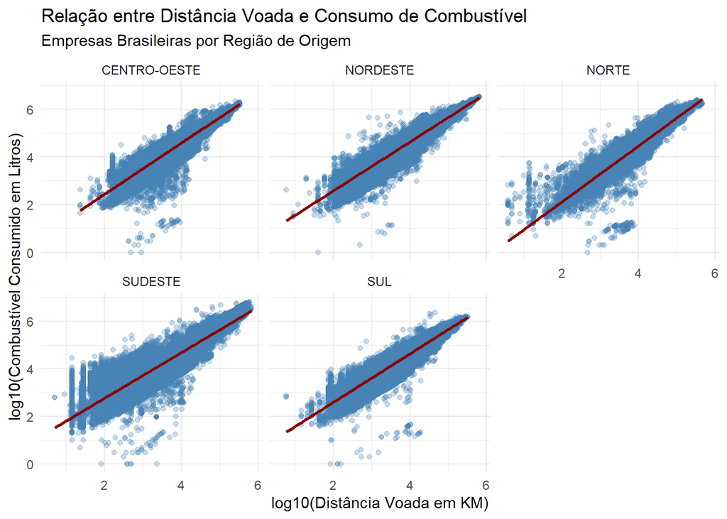

```r
df %>%
  filter(EMPRESA_NACIONALIDADE == "BRASILEIRA",
         !is.na(DISTANCIA_VOADA_KM),
         !is.na(COMBUSTIVEL_LITROS),
         COMBUSTIVEL_LITROS > 0,
         DISTANCIA_VOADA_KM > 0,
         AEROPORTO_DE_ORIGEM_REGIAO != "") %>%
  ggplot(aes(x = log10(DISTANCIA_VOADA_KM), y = log10(COMBUSTIVEL_LITROS))) +
  geom_point(alpha = 0.3, color = "steelblue") +
  geom_smooth(method = "lm", se = FALSE, color = "darkred") +
  facet_wrap(~AEROPORTO_DE_ORIGEM_REGIAO) +
  labs(title = "Relação entre Distância Voada e Consumo de Combustível",
       subtitle = "Empresas Brasileiras por Região de Origem",
       x = "log10(Distância Voada em KM)",
       y = "log10(Combustível Consumido em Litros)") +
  theme_minimal()
```

9. O indicador RTK (Revenue tonne kilometer) refere-se ao volume de toneladas quilômetros transportada. Faça uma visualização da relação deste indicador com o consumo de combustível. Filtre apenas observações com ambas variáveis maiores que zero. Considere também que é de interesse comparar essa relação entre os diferentes anos. Considere incluir alguma camada estatística para enfatizar o formato do relacionamento entre as variáveis.

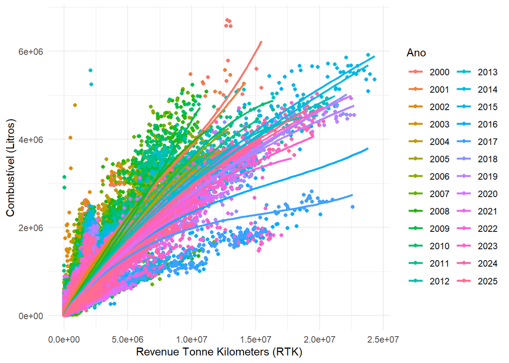

```r
ggplot(df %>%
         filter(RTK > 0 & COMBUSTIVEL_LITROS > 0), aes(x = RTK, y = COMBUSTIVEL_LITROS, color = as.factor(ANO))) +
  geom_point() +
  geom_smooth(method = "loess", se = FALSE) +
  labs(x = "Revenue Tonne Kilometers (RTK)", y = "Combustível (Litros)", color = "Ano") +
  theme_minimal()
```

10. O indicador ATK (Available tonne kilometer) refere-se ao volume de tonelada quilômetro oferecida pela companhia. Crie uma visualização para explorar a relação entre estes indicadores. Considere aspectos como GRUPO_DE_VOO e NATUREZA além do anos.

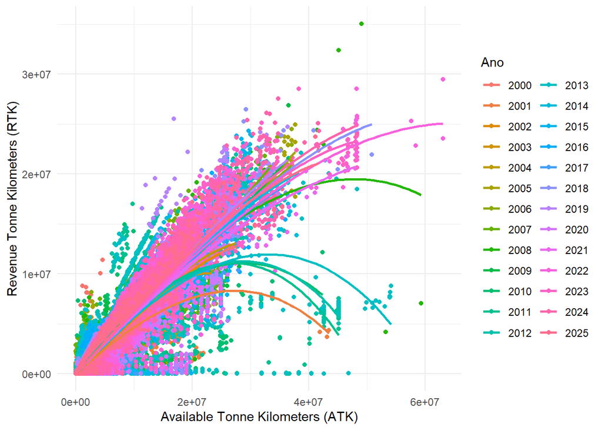

```r
ggplot(df %>%
               filter(ATK > 0 & RTK > 0), aes(x = ATK, y = RTK, color = as.factor(ANO))) +
  geom_point() +
  geom_smooth(method = "loess", se = FALSE) +
  labs(x = "Available Tonne Kilometers (ATK)", y = "Revenue Tonne Kilometers (RTK)", color = "Ano") +
  theme_minimal()
```

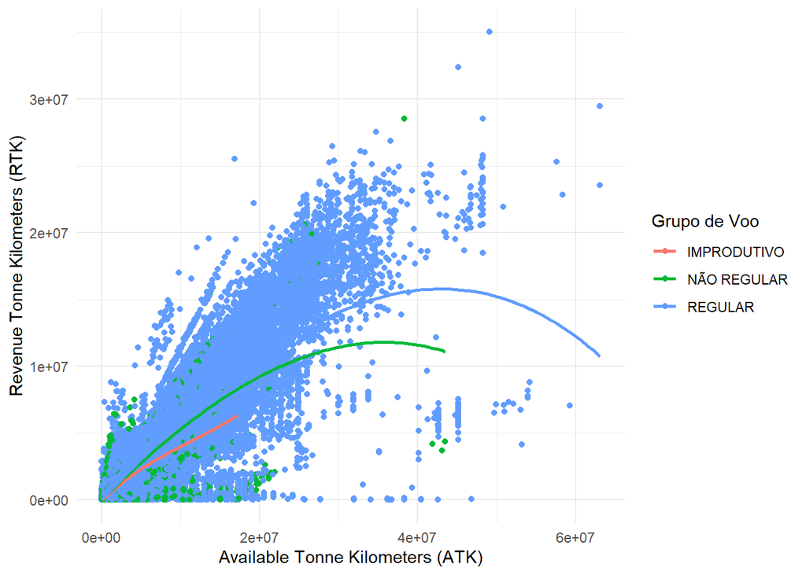

```r
ggplot(df %>%
               filter(ATK > 0 & RTK > 0), aes(x = ATK, y = RTK, color = as.factor(GRUPO_DE_VOO))) +
  geom_point() +
  geom_smooth(method = "loess", se = FALSE) +
  labs(x = "Available Tonne Kilometers (ATK)", y = "Revenue Tonne Kilometers (RTK)", color = "Grupo de Voo") +
  theme_minimal()
```